# DEA analysis for Monthly Farm Data

Jiachuan Tian

Thursday, February 11, 2016

This is an R Markdown document of the DEA analysis of monthly farm data.

## Part 0 Data Description

```r
options(digits=4)
data = read.xlsx(file = 'Monthly.xlsx', 1)
dim(data)
```

```
## [1] 2346   36
```

Farm_ID and Number of Farms

```r
unique(data$Farm_ID)
```

```
##  [1]   3   4   5   9  10  14  18  21  22  23  24  25  31  37  38  51  60
## [18]  61  62  63  65  66  67  69  70  93  95 106 107 111 113 115 129 130
## [35] 133 135 144 146 149 150 153 159 162 163 164 170 179 180 186 194 195
## [52] 196 198
```

```r
length(unique(data$Farm_ID))
```

```
## [1] 53
```

Check Missing Values

```r
missing_fn = function(col_index){
  return(sum(is.na(data[,col_index])))
}
result = sapply(1:dim(data)[2], function(x) missing_fn(x))
missing_value = as.data.frame(result)
missing_value$Var = colnames(data)
colnames(missing_value)[1] = "Number_of_Missing_Values"
missing_value = missing_value[, c(2, 1)]
kable(missing_value, digits = 0, caption = "Number_of_Missing_Values")
```

Number_of_Missing_Values

| Var | Number_of_Missing_Values |
| --- | --- |
| Farm_ID | 0 |
| Herdcode | 0 |
| Milk_per_Milk_Cow | 0 |
| X__Fat | 0 |
| X__Pro | 0 |
| X__Cows | 0 |
| ME_305_Milk | 11 |
| ME_305_Fat | 11 |
| ME_305_Pro | 11 |
| X__Milk_Cows | 0 |
| X_50_D_Milk | 0 |
| Peak | 11 |
| Summit | 11 |
| DHIDate | 0 |
| month | 0 |
| year | 0 |
| Sample_Number | 2184 |
| Season_Year | 2184 |
| MUN | 2185 |
| Dry_Matter | 2184 |
| CP__ | 2184 |
| NDF___DM | 2184 |
| Starch___DM | 2184 |
| Starch_Digestibility | 2184 |
| NDF_Digestibility | 2219 |
| NDF_Dig_Group | 2232 |
| Fecal_Starch | 2184 |
| pH | 2199 |
| Hybrid | 2256 |
| Structure | 2256 |
| SampleDate | 2184 |
| Parent_Company | 2291 |
| Hybrid_Company | 2289 |
| Hybrid_Name | 2291 |
| Trait | 2300 |
| relative_maturity | 2291 |

Data in Sample

```r
sample = data[!is.na(data$Sample_Number), ]
dim(sample)
```

```
## [1] 162  36
```

```r
unique(sample$Farm_ID)
```

```
##  [1]   3   4   5   9  10  14  18  21  22  23  24  25  31  37  38  51  60
## [18]  61  62  63  65  66  67  69  70  93  95 106 107 111 113 115 129 130
## [35] 133 135 144 146 149 150 153 159 162 163 164 170 179 180 186 194 195
## [52] 196 198
```

```r
length(unique(sample$Farm_ID))
```

```
## [1] 53
```

Every Farm has been sampled. Good!

## Part 1 Heterogeneity Test for sample vs. nonsample data

Kruskal Wallis Test

```r
kruskal_test = outer(
  unique(sample$Farm_ID),
  (3:13),
  Vectorize(function(x, y) kruskal_test_fn(x, y, data))
)
kruskal_test = as.data.frame(kruskal_test)
colnames(kruskal_test) = colnames(data)[3:13]
kruskal_test$Farm_ID = unique(data$Farm_ID)
kruskal_test = kruskal_test[,c(12, 1 : 11)]

knitr::kable(kruskal_test, digits =3, caption = "Kruskal Wallis Test ")
```

Kruskal Wallis Test

| Farm_ID | Milk_per_Milk_Cow | X__Fat | X__Pro | X__Cows | ME_305_Milk | ME_305_Fat | ME_305_Pro | X__Milk_Cows | X_50_D_Milk | Peak | Summit |
| --- | --- | --- | --- | --- | --- | --- | --- | --- | --- | --- | --- |
| 3 | 0.129 | 0.498 | 0.876 | 0.211 | 0.970 | 0.614 | 0.970 | 0.191 | 0.599 | 0.763 | 0.837 |
| 4 | 0.553 | 1.000 | 0.237 | 0.863 | 0.732 | 0.277 | 0.775 | 0.200 | 0.803 | 0.539 | 0.310 |
| 5 | 0.166 | 0.031 | 0.929 | 0.556 | 0.155 | 0.867 | 0.103 | 0.450 | 0.120 | 0.476 | 0.238 |
| 9 | 0.442 | 0.219 | 0.212 | 0.510 | 0.208 | 0.149 | 0.130 | 0.214 | 0.143 | 0.486 | 0.647 |
| 10 | 0.490 | 0.676 | 0.463 | 0.136 | 0.295 | 0.349 | 0.363 | 0.186 | 0.308 | 0.107 | 0.103 |
| 14 | 0.140 | 0.920 | 0.836 | 0.255 | 0.202 | 0.675 | 0.264 | 0.202 | 0.162 | 0.327 | 0.603 |
| 18 | 0.855 | 0.250 | 0.510 | 0.125 | 0.342 | 0.097 | 0.298 | 0.062 | 0.783 | 0.486 | 0.673 |
| 21 | 0.888 | 0.700 | 0.783 | 0.216 | 0.202 | 0.750 | 0.290 | 0.264 | 0.574 | 0.794 | 0.674 |
| 22 | 0.898 | 0.516 | 0.038 | 0.201 | 0.535 | 0.112 | 0.165 | 0.182 | 0.418 | 0.295 | 0.555 |
| 23 | 0.667 | 0.289 | 0.859 | 0.837 | 0.765 | 0.955 | 0.641 | 0.654 | 0.985 | 0.276 | 0.375 |
| 24 | 0.553 | 0.151 | 0.706 | 0.734 | 0.115 | 0.871 | 0.064 | 0.816 | 0.733 | 0.816 | 0.779 |
| 25 | 0.082 | 0.532 | 0.970 | 0.927 | 0.028 | 0.443 | 0.026 | 0.596 | 0.009 | 0.378 | 0.157 |
| 31 | 0.534 | 0.698 | 0.495 | 0.071 | 0.111 | 0.478 | 0.087 | 0.084 | 0.515 | 0.374 | 0.657 |
| 37 | 0.132 | 0.818 | 0.904 | 0.537 | 0.158 | 0.295 | 0.152 | 0.767 | 0.058 | 0.492 | 0.272 |
| 38 | 0.942 | 0.926 | 0.354 | 0.647 | 0.971 | 0.985 | 0.913 | 0.314 | 0.898 | 0.798 | 0.883 |
| 51 | 0.650 | 0.084 | 0.937 | 0.754 | 0.371 | 0.101 | 0.179 | 0.128 | 0.323 | 0.500 | 0.177 |
| 60 | 0.219 | 0.318 | 0.163 | 0.642 | 0.715 | 0.361 | 0.770 | 0.198 | 0.212 | 0.123 | 0.233 |
| 61 | 0.882 | 0.530 | 0.030 | 0.858 | 0.953 | 0.478 | 0.929 | 0.376 | 0.700 | 0.976 | 0.236 |
| 62 | 0.089 | 0.447 | 0.196 | 0.723 | 0.075 | 0.067 | 0.177 | 0.870 | 0.448 | 0.074 | 0.051 |
| 63 | 0.235 | 0.817 | 0.578 | 0.934 | 0.391 | 0.450 | 0.102 | 0.557 | 0.176 | 0.951 | 0.445 |
| 65 | 0.594 | 0.065 | 0.722 | 0.607 | 0.488 | 0.104 | 0.742 | 0.839 | 0.839 | 0.289 | 0.065 |
| 66 | 0.736 | 0.469 | 0.633 | 0.391 | 1.000 | 0.131 | 0.780 | 0.422 | 0.779 | 0.678 | 0.719 |
| 67 | 0.148 | 0.270 | 0.962 | 0.360 | 0.965 | 0.896 | 0.695 | 0.526 | 0.615 | 0.825 | 0.842 |
| 69 | 0.278 | 0.607 | 0.373 | 0.455 | 0.911 | 0.970 | 0.563 | 0.211 | 0.378 | 0.638 | 0.427 |
| 70 | 0.608 | 0.556 | 0.678 | 0.342 | 0.465 | 0.214 | 0.306 | 0.841 | 0.647 | 0.782 | 0.417 |
| 93 | 0.064 | 0.507 | 0.184 | 0.214 | 0.337 | 0.404 | 0.448 | 0.432 | 0.224 | 0.299 | 0.403 |
| 95 | 0.787 | 0.402 | 0.655 | 0.914 | 0.161 | 0.306 | 0.258 | 0.686 | 0.570 | 0.082 | 0.073 |
| 106 | 0.058 | 0.211 | 0.236 | 0.673 | 0.216 | 0.549 | 0.163 | 0.422 | 0.060 | 0.412 | 0.161 |
| 107 | 0.453 | 0.245 | 0.407 | 0.504 | 0.827 | 0.257 | 0.559 | 0.633 | 0.583 | 0.199 | 0.431 |
| 111 | 0.032 | 0.022 | 0.358 | 0.436 | 0.044 | 0.038 | 0.033 | 0.435 | 0.021 | 0.087 | 0.258 |
| 113 | 0.608 | 0.849 | 0.885 | 0.428 | 0.295 | 0.184 | 0.295 | 0.415 | 0.388 | 0.944 | 0.560 |
| 115 | 0.761 | 0.589 | 0.749 | 0.109 | 0.419 | 0.404 | 0.840 | 0.049 | 0.839 | 0.919 | 0.859 |
| 129 | 0.533 | 0.152 | 0.402 | 0.315 | 0.798 | 0.083 | 0.841 | 0.432 | 0.248 | 0.672 | 0.970 |
| 130 | 0.909 | 0.455 | 0.346 | 0.924 | 0.237 | 0.097 | 0.331 | 0.774 | 0.593 | 0.515 | 0.433 |
| 133 | 0.747 | 0.817 | 0.019 | 0.023 | 0.262 | 0.137 | 0.647 | 0.582 | 0.748 | 0.181 | 0.100 |
| 135 | 0.516 | 0.904 | 0.851 | 0.768 | 0.346 | 0.701 | 0.461 | 0.596 | 0.953 | 0.976 | 0.858 |
| 144 | 0.138 | 0.053 | 0.732 | 0.131 | 0.616 | 0.595 | 0.813 | 0.062 | 0.285 | 0.062 | 0.088 |
| 146 | 0.687 | 0.255 | 0.616 | 0.247 | 0.361 | 0.250 | 0.182 | 0.278 | 0.399 | 0.484 | 0.398 |
| 149 | 0.264 | 0.229 | 0.193 | 0.245 | 0.414 | 0.692 | 0.347 | 0.131 | 0.320 | 0.371 | 0.274 |
| 150 | 0.135 | 0.459 | 0.163 | 0.090 | 0.312 | 0.613 | 0.419 | 0.072 | 0.180 | 0.542 | 0.431 |
| 153 | 0.485 | 1.000 | 0.848 | 0.183 | 0.614 | 0.529 | 0.753 | 0.613 | 0.447 | 0.403 | 0.370 |
| 159 | 0.199 | 0.062 | 0.131 | 0.089 | 0.609 | 0.454 | 1.000 | 0.058 | 0.226 | 0.496 | 0.158 |
| 162 | 0.569 | 0.699 | 0.379 | 0.079 | 0.488 | 0.177 | 0.298 | 0.062 | 0.956 | 0.545 | 0.367 |
| 163 | 0.601 | 0.727 | 0.783 | 0.139 | 0.664 | 0.544 | 0.931 | 0.725 | 0.338 | 0.794 | 0.793 |
| 164 | 0.077 | 0.715 | 0.269 | 0.576 | 0.395 | 0.170 | 0.226 | 0.358 | 0.071 | 0.948 | 0.742 |
| 170 | 0.869 | 0.740 | 0.757 | 0.119 | 0.196 | 0.186 | 0.168 | 0.211 | 0.912 | 0.161 | 0.211 |
| 179 | 0.074 | 0.733 | 0.971 | 0.145 | 0.314 | 0.313 | 0.420 | 0.661 | 0.167 | 0.308 | 0.277 |
| 180 | 0.899 | 0.052 | 0.308 | 0.109 | 0.920 | 0.245 | 0.705 | 0.144 | 1.000 | 0.800 | 0.780 |
| 186 | 0.266 | 0.135 | 0.909 | 0.476 | 0.673 | 0.092 | 0.562 | 0.107 | 0.314 | 0.264 | 0.221 |
| 194 | 0.550 | 0.620 | 0.746 | 0.407 | 0.135 | 0.454 | 0.680 | 0.352 | 0.501 | 0.336 | 0.495 |
| 195 | 0.053 | 0.364 | 0.277 | 0.454 | 0.099 | 0.050 | 0.079 | 0.224 | 0.083 | 0.171 | 0.171 |
| 196 | 0.427 | 0.812 | 0.508 | 0.257 | 0.206 | 0.399 | 0.268 | 0.140 | 0.300 | 0.381 | 0.289 |
| 198 | 0.481 | 0.194 | 0.274 | 0.123 | 0.161 | 0.085 | 0.306 | 0.034 | 0.829 | 0.213 | 0.137 |

Kolmogorov-Smirnov Test (two-sided)

```r
ks_test = outer(
  unique(sample$Farm_ID),
  (3:13),
  Vectorize(function(x, y) ks_test_fn(x, y, data))
)
ks_test = as.data.frame(ks_test)
colnames(ks_test) = colnames(data)[3:13]
ks_test$Farm_ID = unique(data$Farm_ID)
ks_test = ks_test[,c(12, 1 : 11)]
```

```r
knitr::kable(ks_test, digits = 3, caption = "Kolmogorov-Smirnov Test")
```

Kolmogorov-Smirnov Test

| Farm_ID | Milk_per_Milk_Cow | X__Fat | X__Pro | X__Cows | ME_305_Milk | ME_305_Fat | ME_305_Pro | X__Milk_Cows | X_50_D_Milk | Peak | Summit |
| --- | --- | --- | --- | --- | --- | --- | --- | --- | --- | --- | --- |
| 3 | 0.374 | 0.976 | 0.998 | 0.717 | 0.788 | 0.788 | 0.852 | 0.501 | 0.948 | 0.991 | 1.000 |
| 4 | 0.892 | 1.000 | 0.473 | 0.999 | 0.944 | 0.347 | 0.985 | 0.456 | 0.956 | 0.598 | 0.747 |
| 5 | 0.412 | 0.122 | 0.999 | 0.564 | 0.172 | 0.999 | 0.085 | 0.260 | 0.315 | 0.876 | 0.564 |
| 9 | 0.742 | 0.809 | 0.416 | 0.896 | 0.293 | 0.076 | 0.247 | 0.344 | 0.258 | 0.431 | 0.707 |
| 10 | 0.965 | 0.871 | 0.726 | 0.240 | 0.392 | 0.645 | 0.438 | 0.350 | 0.392 | 0.274 | 0.274 |
| 14 | 0.366 | 0.971 | 1.000 | 0.164 | 0.448 | 0.977 | 0.382 | 0.351 | 0.308 | 0.857 | 0.982 |
| 18 | 0.956 | 0.671 | 0.869 | 0.416 | 0.293 | 0.293 | 0.293 | 0.258 | 0.689 | 0.599 | 0.869 |
| 21 | 0.937 | 0.956 | 1.000 | 0.577 | 0.558 | 0.986 | 0.857 | 0.733 | 0.733 | 0.789 | 0.977 |
| 22 | 0.869 | 0.970 | 0.142 | 0.247 | 0.599 | 0.076 | 0.529 | 0.293 | 0.956 | 0.689 | 0.970 |
| 23 | 0.906 | 0.269 | 1.000 | 0.852 | 0.991 | 0.991 | 0.717 | 0.788 | 0.998 | 0.571 | 0.948 |
| 24 | 0.765 | 0.227 | 0.998 | 0.885 | 0.228 | 0.365 | 0.090 | 0.858 | 0.626 | 0.903 | 0.903 |
| 25 | 0.416 | 0.809 | 1.000 | 0.883 | 0.095 | 0.344 | 0.076 | 0.883 | 0.030 | 0.546 | 0.293 |
| 31 | 0.783 | 0.952 | 0.835 | 0.175 | 0.234 | 0.555 | 0.203 | 0.203 | 0.783 | 0.446 | 0.728 |
| 37 | 0.138 | 0.997 | 1.000 | 0.549 | 0.234 | 0.615 | 0.166 | 0.951 | 0.138 | 0.976 | 0.749 |
| 38 | 0.976 | 1.000 | 0.956 | 0.809 | 0.930 | 0.993 | 0.930 | 0.357 | 0.896 | 0.896 | 0.988 |
| 51 | 0.770 | 0.299 | 0.895 | 1.000 | 0.640 | 0.299 | 0.549 | 0.697 | 0.770 | 0.770 | 0.413 |
| 60 | 0.617 | 0.939 | 0.371 | 0.997 | 0.617 | 0.344 | 0.825 | 0.529 | 0.371 | 0.172 | 0.400 |
| 61 | 0.999 | 0.974 | 0.128 | 0.988 | 0.664 | 0.397 | 0.728 | 0.974 | 0.974 | 0.952 | 0.397 |
| 62 | 0.134 | 0.938 | 0.467 | 0.996 | 0.134 | 0.099 | 0.232 | 0.776 | 0.824 | 0.203 | 0.134 |
| 63 | 0.527 | 0.765 | 0.977 | 0.899 | 0.453 | 0.606 | 0.221 | 0.765 | 0.606 | 0.999 | 0.837 |
| 65 | 0.993 | 0.247 | 0.981 | 0.970 | 0.840 | 0.258 | 0.956 | 0.988 | 0.999 | 0.883 | 0.305 |
| 66 | 0.906 | 0.948 | 0.948 | 0.501 | 0.976 | 0.318 | 0.976 | 0.571 | 0.991 | 0.998 | 0.906 |
| 67 | 0.147 | 0.900 | 1.000 | 0.484 | 0.927 | 0.985 | 0.885 | 0.852 | 0.735 | 1.000 | 0.735 |
| 69 | 0.644 | 0.998 | 0.998 | 0.435 | 0.906 | 0.976 | 0.906 | 0.435 | 0.717 | 0.976 | 0.788 |
| 70 | 0.985 | 0.635 | 0.999 | 0.919 | 0.479 | 0.172 | 0.416 | 0.970 | 0.985 | 0.981 | 0.742 |
| 93 | 0.301 | 0.724 | 0.859 | 0.415 | 0.374 | 0.859 | 0.415 | 0.551 | 0.748 | 0.336 | 0.551 |
| 95 | 0.999 | 0.824 | 0.824 | 0.776 | 0.178 | 0.567 | 0.377 | 0.824 | 0.906 | 0.377 | 0.421 |
| 106 | 0.090 | 0.636 | 0.887 | 0.655 | 0.295 | 0.937 | 0.295 | 0.414 | 0.245 | 0.926 | 0.502 |
| 107 | 0.919 | 0.671 | 0.930 | 0.988 | 0.869 | 0.463 | 0.529 | 0.939 | 0.400 | 0.479 | 0.825 |
| 111 | 0.090 | 0.063 | 0.586 | 0.856 | 0.062 | 0.090 | 0.090 | 0.917 | 0.053 | 0.226 | 0.296 |
| 113 | 0.977 | 0.941 | 1.000 | 0.456 | 0.343 | 0.250 | 0.456 | 0.343 | 0.829 | 0.962 | 0.900 |
| 115 | 0.993 | 0.878 | 0.817 | 0.336 | 0.374 | 0.551 | 0.650 | 0.108 | 0.996 | 0.838 | 0.795 |
| 129 | 0.689 | 0.258 | 0.939 | 0.599 | 0.617 | 0.207 | 0.976 | 0.416 | 0.689 | 0.964 | 0.993 |
| 130 | 0.999 | 0.878 | 0.878 | 0.800 | 0.407 | 0.112 | 0.654 | 0.800 | 0.863 | 0.747 | 0.473 |
| 133 | 0.895 | 0.650 | 0.280 | 0.026 | 0.344 | 0.110 | 0.650 | 0.539 | 0.475 | 0.202 | 0.110 |
| 135 | 0.583 | 1.000 | 0.964 | 0.835 | 0.583 | 0.974 | 0.499 | 0.921 | 0.995 | 1.000 | 0.995 |
| 144 | 0.269 | 0.203 | 0.995 | 0.175 | 0.612 | 0.670 | 0.783 | 0.128 | 0.499 | 0.175 | 0.351 |
| 146 | 0.776 | 0.357 | 1.000 | 0.930 | 0.742 | 0.546 | 0.400 | 0.776 | 0.776 | 0.759 | 0.416 |
| 149 | 0.770 | 0.361 | 0.970 | 0.441 | 0.770 | 0.770 | 0.675 | 0.441 | 0.626 | 0.770 | 0.626 |
| 150 | 0.301 | 0.979 | 0.600 | 0.210 | 0.301 | 0.838 | 0.458 | 0.210 | 0.268 | 0.650 | 0.838 |
| 153 | 0.866 | 0.996 | 0.996 | 0.693 | 0.557 | 0.735 | 0.866 | 0.947 | 0.693 | 0.911 | 0.911 |
| 159 | 0.479 | 0.216 | 0.546 | 0.142 | 0.825 | 0.689 | 0.742 | 0.142 | 0.529 | 0.759 | 0.344 |
| 162 | 0.825 | 0.991 | 0.985 | 0.095 | 0.809 | 0.293 | 0.599 | 0.049 | 0.985 | 0.599 | 0.689 |
| 163 | 0.843 | 0.955 | 1.000 | 0.361 | 0.843 | 0.700 | 0.955 | 0.983 | 0.681 | 0.908 | 0.908 |
| 164 | 0.171 | 0.848 | 0.994 | 0.667 | 0.760 | 0.479 | 0.479 | 0.602 | 0.202 | 0.999 | 1.000 |
| 170 | 0.995 | 0.871 | 0.871 | 0.210 | 0.438 | 0.240 | 0.210 | 0.310 | 0.995 | 0.210 | 0.392 |
| 179 | 0.177 | 0.999 | 0.999 | 0.210 | 0.289 | 0.794 | 0.443 | 0.941 | 0.387 | 0.824 | 0.633 |
| 180 | 0.817 | 0.124 | 0.859 | 0.374 | 0.999 | 0.551 | 0.985 | 0.458 | 0.817 | 0.928 | 0.859 |
| 186 | 0.496 | 0.254 | 0.998 | 0.647 | 0.725 | 0.172 | 0.775 | 0.323 | 0.596 | 0.822 | 0.596 |
| 194 | 0.931 | 0.975 | 0.899 | 0.476 | 0.246 | 0.862 | 0.674 | 0.476 | 0.956 | 0.476 | 0.931 |
| 195 | 0.110 | 0.623 | 0.573 | 0.674 | 0.127 | 0.095 | 0.110 | 0.573 | 0.246 | 0.431 | 0.389 |
| 196 | 0.449 | 0.844 | 0.750 | 0.449 | 0.323 | 0.496 | 0.545 | 0.254 | 0.545 | 0.750 | 0.844 |
| 198 | 0.776 | 0.938 | 0.990 | 0.467 | 0.232 | 0.115 | 0.516 | 0.134 | 0.776 | 0.377 | 0.298 |

Wilcoxon Rank Sum Test(equivalently Mann-Whitney test)

```r
wilcox_test = outer(
  unique(sample$Farm_ID),
  (3:13),
  Vectorize(function(x, y) wilcox_test_fn(x, y, data))
)
wilcox_test = as.data.frame(wilcox_test)
colnames(wilcox_test) = colnames(data)[3:13]
wilcox_test$Farm_ID = unique(data$Farm_ID)
wilcox_test = wilcox_test[,c(12, 1 : 11)]
```

```r
knitr::kable(wilcox_test, digits = 3, caption = "Wilcoxon Rank Sum Test")
```

Wilcoxon Rank Sum Test

| Farm_ID | Milk_per_Milk_Cow | X__Fat | X__Pro | X__Cows | ME_305_Milk | ME_305_Fat | ME_305_Pro | X__Milk_Cows | X_50_D_Milk | Peak | Summit |
| --- | --- | --- | --- | --- | --- | --- | --- | --- | --- | --- | --- |
| 3 | 0.134 | 0.510 | 0.891 | 0.218 | 0.985 | 0.628 | 0.985 | 0.198 | 0.613 | 0.778 | 0.851 |
| 4 | 0.566 | 1.000 | 0.246 | 0.878 | 0.755 | 0.286 | 0.789 | 0.206 | 0.818 | 0.552 | 0.319 |
| 5 | 0.180 | 0.034 | 0.964 | 0.585 | 0.168 | 0.900 | 0.112 | 0.475 | 0.130 | 0.502 | 0.255 |
| 9 | 0.453 | 0.226 | 0.219 | 0.522 | 0.214 | 0.154 | 0.134 | 0.221 | 0.148 | 0.498 | 0.660 |
| 10 | 0.508 | 0.696 | 0.481 | 0.143 | 0.308 | 0.363 | 0.378 | 0.195 | 0.321 | 0.114 | 0.109 |
| 14 | 0.145 | 0.936 | 0.852 | 0.264 | 0.209 | 0.690 | 0.273 | 0.209 | 0.168 | 0.337 | 0.617 |
| 18 | 0.869 | 0.258 | 0.523 | 0.129 | 0.352 | 0.100 | 0.306 | 0.065 | 0.797 | 0.497 | 0.687 |
| 21 | 0.904 | 0.715 | 0.800 | 0.223 | 0.209 | 0.765 | 0.299 | 0.272 | 0.588 | 0.810 | 0.689 |
| 22 | 0.912 | 0.528 | 0.040 | 0.208 | 0.547 | 0.116 | 0.171 | 0.188 | 0.428 | 0.304 | 0.568 |
| 23 | 0.680 | 0.297 | 0.875 | 0.852 | 0.780 | 0.970 | 0.654 | 0.667 | 1.000 | 0.284 | 0.386 |
| 24 | 0.566 | 0.156 | 0.720 | 0.747 | 0.121 | 0.889 | 0.067 | 0.830 | 0.747 | 0.834 | 0.797 |
| 25 | 0.085 | 0.544 | 0.985 | 0.942 | 0.030 | 0.454 | 0.027 | 0.609 | 0.010 | 0.388 | 0.163 |
| 31 | 0.553 | 0.720 | 0.514 | 0.075 | 0.118 | 0.497 | 0.092 | 0.089 | 0.534 | 0.390 | 0.679 |
| 37 | 0.138 | 0.836 | 0.923 | 0.552 | 0.165 | 0.306 | 0.158 | 0.784 | 0.061 | 0.507 | 0.283 |
| 38 | 0.956 | 0.941 | 0.364 | 0.660 | 0.985 | 1.000 | 0.927 | 0.323 | 0.913 | 0.812 | 0.898 |
| 51 | 0.705 | 0.099 | 1.000 | 0.814 | 0.441 | 0.117 | 0.205 | 0.148 | 0.362 | 0.549 | 0.202 |
| 60 | 0.226 | 0.327 | 0.169 | 0.655 | 0.729 | 0.371 | 0.784 | 0.205 | 0.219 | 0.128 | 0.240 |
| 61 | 0.906 | 0.550 | 0.032 | 0.882 | 0.976 | 0.497 | 0.953 | 0.393 | 0.722 | 1.000 | 0.248 |
| 62 | 0.094 | 0.464 | 0.206 | 0.744 | 0.080 | 0.071 | 0.186 | 0.892 | 0.465 | 0.079 | 0.055 |
| 63 | 0.243 | 0.833 | 0.592 | 0.950 | 0.403 | 0.462 | 0.107 | 0.571 | 0.183 | 0.967 | 0.457 |
| 65 | 0.607 | 0.068 | 0.737 | 0.620 | 0.499 | 0.108 | 0.756 | 0.853 | 0.854 | 0.298 | 0.068 |
| 66 | 0.750 | 0.481 | 0.647 | 0.401 | 1.000 | 0.135 | 0.794 | 0.433 | 0.793 | 0.692 | 0.734 |
| 67 | 0.155 | 0.279 | 0.981 | 0.371 | 0.983 | 0.913 | 0.711 | 0.541 | 0.631 | 0.842 | 0.860 |
| 69 | 0.286 | 0.620 | 0.385 | 0.467 | 0.926 | 0.985 | 0.576 | 0.218 | 0.388 | 0.652 | 0.439 |
| 70 | 0.621 | 0.569 | 0.693 | 0.351 | 0.476 | 0.221 | 0.315 | 0.855 | 0.660 | 0.796 | 0.428 |
| 93 | 0.068 | 0.524 | 0.193 | 0.223 | 0.350 | 0.419 | 0.464 | 0.447 | 0.234 | 0.310 | 0.418 |
| 95 | 0.808 | 0.417 | 0.675 | 0.935 | 0.170 | 0.319 | 0.269 | 0.706 | 0.589 | 0.087 | 0.077 |
| 106 | 0.060 | 0.219 | 0.245 | 0.688 | 0.224 | 0.563 | 0.169 | 0.434 | 0.063 | 0.424 | 0.167 |
| 107 | 0.464 | 0.253 | 0.418 | 0.516 | 0.841 | 0.265 | 0.571 | 0.647 | 0.596 | 0.205 | 0.441 |
| 111 | 0.035 | 0.024 | 0.374 | 0.453 | 0.035 | 0.041 | 0.035 | 0.453 | 0.022 | 0.092 | 0.270 |
| 113 | 0.624 | 0.867 | 0.904 | 0.442 | 0.306 | 0.192 | 0.306 | 0.428 | 0.401 | 0.963 | 0.575 |
| 115 | 0.780 | 0.607 | 0.769 | 0.114 | 0.433 | 0.419 | 0.860 | 0.052 | 0.859 | 0.939 | 0.879 |
| 129 | 0.545 | 0.157 | 0.413 | 0.324 | 0.812 | 0.086 | 0.855 | 0.443 | 0.255 | 0.685 | 0.985 |
| 130 | 0.924 | 0.466 | 0.357 | 0.939 | 0.245 | 0.101 | 0.340 | 0.789 | 0.606 | 0.527 | 0.444 |
| 133 | 0.765 | 0.835 | 0.021 | 0.025 | 0.272 | 0.143 | 0.664 | 0.598 | 0.766 | 0.189 | 0.105 |
| 135 | 0.535 | 0.928 | 0.875 | 0.791 | 0.361 | 0.723 | 0.479 | 0.616 | 0.976 | 1.000 | 0.881 |
| 144 | 0.146 | 0.057 | 0.756 | 0.139 | 0.637 | 0.616 | 0.836 | 0.066 | 0.299 | 0.066 | 0.093 |
| 146 | 0.700 | 0.263 | 0.630 | 0.254 | 0.371 | 0.257 | 0.188 | 0.286 | 0.410 | 0.495 | 0.408 |
| 149 | 0.275 | 0.239 | 0.202 | 0.255 | 0.428 | 0.710 | 0.360 | 0.137 | 0.332 | 0.385 | 0.285 |
| 150 | 0.142 | 0.475 | 0.171 | 0.095 | 0.324 | 0.631 | 0.433 | 0.077 | 0.188 | 0.559 | 0.446 |
| 153 | 0.526 | 1.000 | 0.899 | 0.205 | 0.676 | 0.591 | 0.801 | 0.658 | 0.486 | 0.440 | 0.406 |
| 159 | 0.205 | 0.065 | 0.137 | 0.093 | 0.622 | 0.465 | 1.000 | 0.060 | 0.233 | 0.507 | 0.164 |
| 162 | 0.582 | 0.713 | 0.390 | 0.083 | 0.499 | 0.182 | 0.306 | 0.065 | 0.971 | 0.557 | 0.376 |
| 163 | 0.663 | 0.793 | 0.854 | 0.164 | 0.729 | 0.700 | 1.000 | 0.792 | 0.384 | 0.862 | 0.861 |
| 164 | 0.083 | 0.740 | 0.285 | 0.598 | 0.444 | 0.180 | 0.239 | 0.375 | 0.076 | 0.974 | 0.767 |
| 170 | 0.890 | 0.761 | 0.779 | 0.126 | 0.205 | 0.195 | 0.177 | 0.222 | 0.934 | 0.169 | 0.221 |
| 179 | 0.079 | 0.759 | 1.000 | 0.154 | 0.330 | 0.329 | 0.440 | 0.686 | 0.178 | 0.325 | 0.292 |
| 180 | 0.919 | 0.056 | 0.320 | 0.115 | 0.940 | 0.255 | 0.723 | 0.151 | 1.000 | 0.819 | 0.799 |
| 186 | 0.278 | 0.143 | 0.932 | 0.492 | 0.693 | 0.097 | 0.580 | 0.113 | 0.327 | 0.275 | 0.231 |
| 194 | 0.568 | 0.638 | 0.766 | 0.422 | 0.141 | 0.470 | 0.699 | 0.366 | 0.517 | 0.350 | 0.512 |
| 195 | 0.056 | 0.378 | 0.289 | 0.470 | 0.104 | 0.053 | 0.084 | 0.234 | 0.088 | 0.179 | 0.179 |
| 196 | 0.443 | 0.832 | 0.526 | 0.268 | 0.215 | 0.414 | 0.280 | 0.147 | 0.312 | 0.396 | 0.302 |
| 198 | 0.498 | 0.204 | 0.288 | 0.130 | 0.170 | 0.090 | 0.319 | 0.037 | 0.850 | 0.223 | 0.144 |

#### Conclusion: No heterogeneity of sample vs nonsample.

## Part 2 Examine heterogeneity of Number of Cows across farms

```r
kruskal.test(data$X__Cows ~ data$Farm_ID)
```

```
##
##  Kruskal-Wallis rank sum test
##
## data:  data$X__Cows by data$Farm_ID
## Kruskal-Wallis chi-squared = 2300, df = 52, p-value <2e-16
```

Histogram Plot Number of Cows by Farm_ID

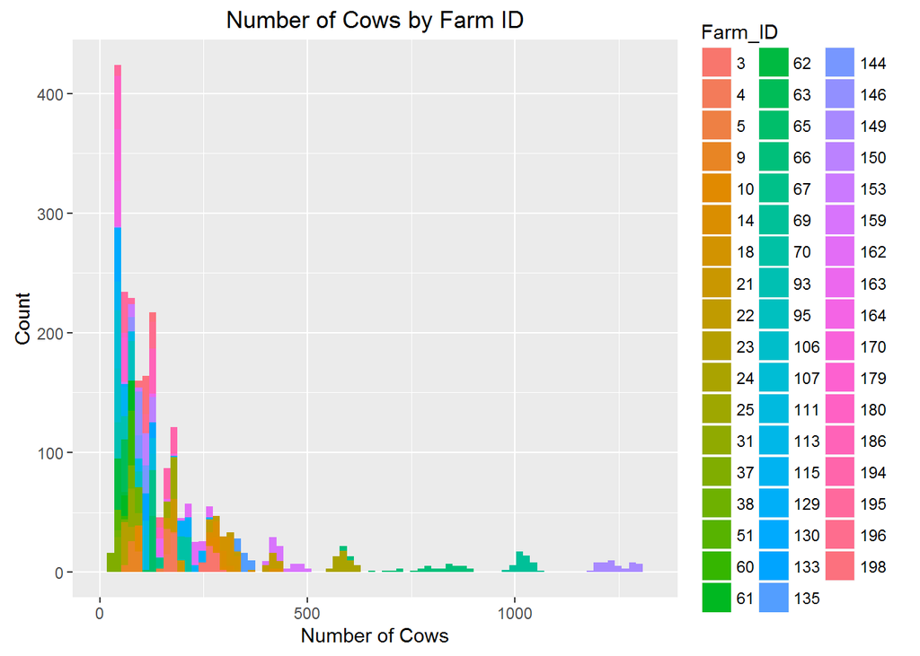

```r
library(ggplot2)
data$Farm_ID = factor(data$Farm_ID)
ggplot(data = data, aes(x = X__Cows,  fill = Farm_ID))+
geom_histogram(binwidth = 17)+
xlab('Number of Cows') +
ylab('Count') +
ggtitle('Number of Cows by Farm ID')+
labs(colour = "Farm ID")
```

Frequency Plot Number of Cows by Farm_ID

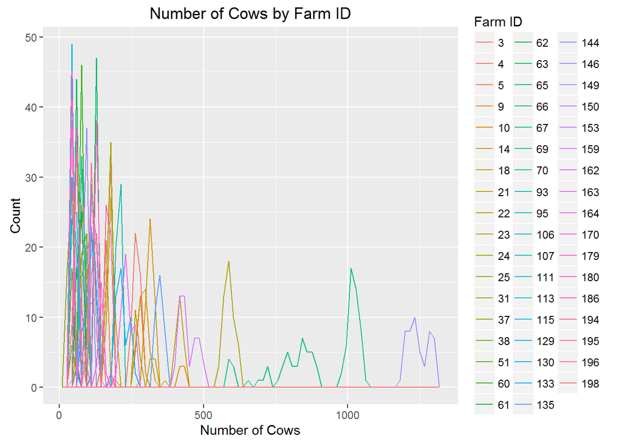

```r
ggplot(data, aes(X__Cows, colour = Farm_ID)) +
geom_freqpoly(binwidth = 17)+
xlab('Number of Cows') +
ylab('Count') +
ggtitle('Number of Cows by Farm ID')+
labs(colour = "Farm ID")
```

Conclusion: There is heterogeneity across farms.

## Part 3 DEA

```r
dea_Milk = dea(data$X__Milk_Cows, data$Milk_per_Milk_Cow)
dea_fat = dea(data$X__Milk_Cows, data$X__Fat)
dea_pro = dea(data$X__Milk_Cows, data$X__Pro)
eff = cbind(dea_Milk$eff, dea_fat$eff, dea_pro$eff)
eff = as.data.frame(eff)
colnames(eff) = colnames(data)[7:9]
eff$Farm_ID = data$Farm_ID
eff = eff[,c(4,1,2,3)]
```

Summary of efficiencies

```r
summary(dea_Milk)
```

```
## Summary of efficiencies
## The technology is vrs and input orientated efficiency
## Number of firms with efficiency==1 are 9
## Mean efficiency: 0.334
## ---
##   Eff range        #     %
##   0<= E <0.1     374 15.94
##   0.1<= E <0.2   443 18.88
##   0.2<= E <0.3   454 19.35
##   0.3<= E <0.4   290 12.36
##   0.4<= E <0.5   201  8.57
##   0.5<= E <0.6   174  7.42
##   0.6<= E <0.7   202  8.61
##   0.7<= E <0.8   113  4.82
##   0.8<= E <0.9    65  2.77
##   0.9<= E <1      21  0.90
##         E ==1      9  0.38
##    Min. 1st Qu.  Median    Mean 3rd Qu.    Max.
##  0.0227  0.1460  0.2730  0.3340  0.4990  1.0000
```

```r
summary(dea_pro)
```

```
## Summary of efficiencies
## The technology is vrs and input orientated efficiency
## Number of firms with efficiency==1 are 6
## Mean efficiency: 0.323
## ---
##   Eff range        #     %
##   0<= E <0.1     419 17.86
##   0.1<= E <0.2   443 18.88
##   0.2<= E <0.3   439 18.71
##   0.3<= E <0.4   299 12.75
##   0.4<= E <0.5   179  7.63
##   0.5<= E <0.6   204  8.70
##   0.6<= E <0.7   185  7.89
##   0.7<= E <0.8    99  4.22
##   0.8<= E <0.9    62  2.64
##   0.9<= E <1      11  0.47
##         E ==1      6  0.26
##    Min. 1st Qu.  Median    Mean 3rd Qu.    Max.
##   0.021   0.141   0.258   0.323   0.490   1.000
```

```r
summary(dea_fat)
```

```
## Summary of efficiencies
## The technology is vrs and input orientated efficiency
## Number of firms with efficiency==1 are 7
## Mean efficiency: 0.326
## ---
##   Eff range        #    %
##   0<= E <0.1     418 17.8
##   0.1<= E <0.2   440 18.8
##   0.2<= E <0.3   430 18.3
##   0.3<= E <0.4   307 13.1
##   0.4<= E <0.5   184  7.8
##   0.5<= E <0.6   187  8.0
##   0.6<= E <0.7   187  8.0
##   0.7<= E <0.8   104  4.4
##   0.8<= E <0.9    68  2.9
##   0.9<= E <1      14  0.6
##         E ==1      7  0.3
##    Min. 1st Qu.  Median    Mean 3rd Qu.    Max.
##   0.021   0.141   0.260   0.326   0.490   1.000
```

Plot of Efficient Frontier of Milk per Milk Cow

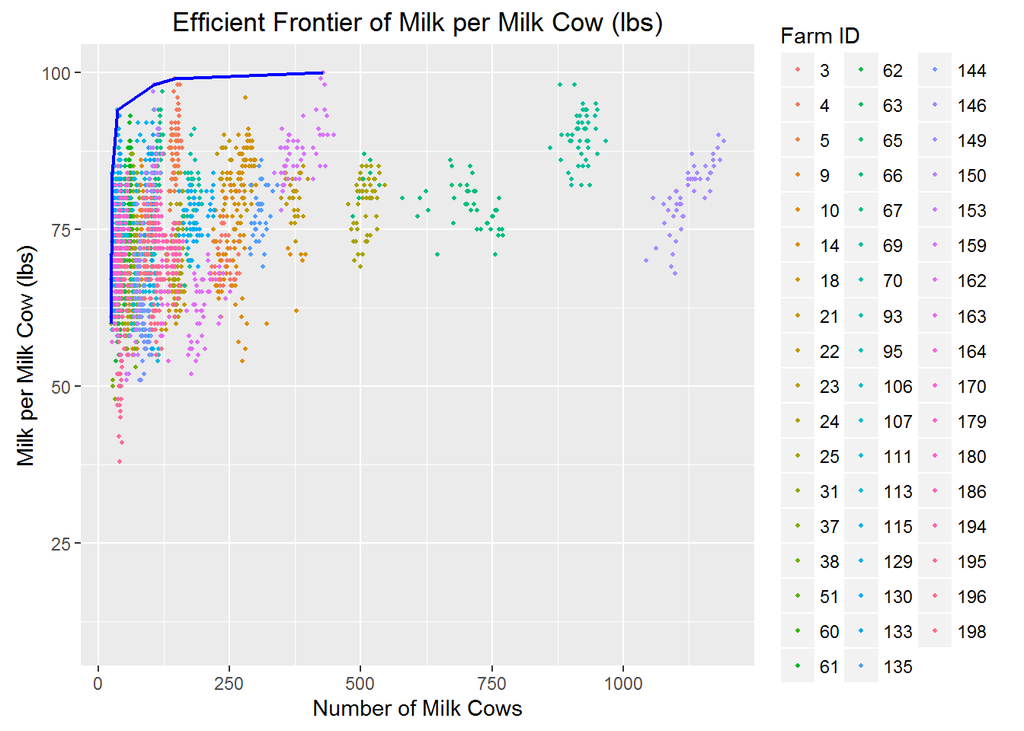

```r
ggplot(data, aes(X__Milk_Cows, Milk_per_Milk_Cow , colour = Farm_ID))+
geom_point(size = .7)+
ylim(10, 100)+
geom_segment(aes(x = 25, y = 60 , xend = 25, yend = 71), size = .8, color = 4)+
geom_segment(aes(x = 25, y = 71, xend = 27, yend = 84), size = .8, color = 4)+
geom_segment(aes(x = 27, y = 84, xend = 36, yend = 94), size = .8, color = 4)+
geom_segment(aes(x = 36, y = 94, xend = 106, yend = 98), size = .8, color = 4)+
geom_segment(aes(x = 106, y = 98, xend = 145, yend = 99), size = .8, color = 4)+
geom_segment(aes(x = 145, y = 99, xend = 429, yend = 100), size = .8, color = 4)+
xlab('Number of Milk Cows') +
ylab('Milk per Milk Cow (lbs)') +
ggtitle('Efficient Frontier of Milk per Milk Cow (lbs)')+
labs(colour = "Farm ID")
```

Plot of Efficient Frontier of Fat

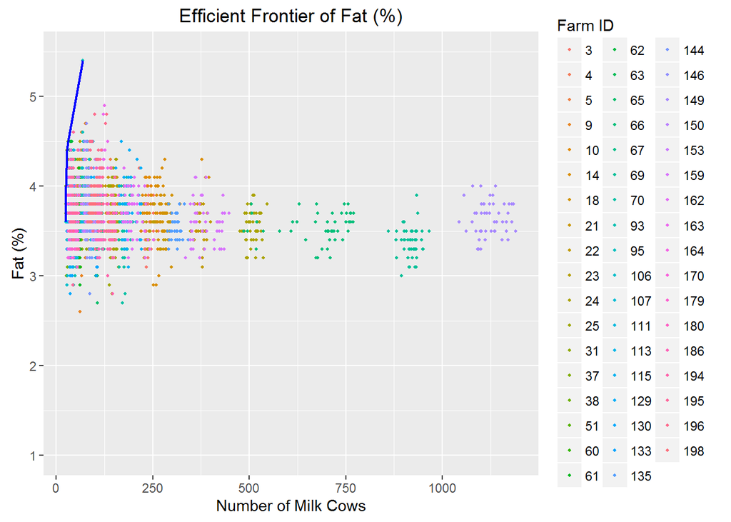

```r
ggplot(data, aes(X__Milk_Cows, X__Fat, colour = Farm_ID))+
geom_point(size = .7)+
ylim(1, 5.5)+
geom_segment(aes(x = 25, y = 3.6, xend = 25, yend = 4.0), size = .8, color = 4)+
geom_segment(aes(x = 25, y = 4.0, xend = 28, yend = 4.4), size = .8, color = 4)+
geom_segment(aes(x = 28, y = 4.4, xend = 31, yend = 4.5), size = .8, color = 4)+
geom_segment(aes(x = 31, y = 4.5, xend = 69, yend = 5.4), size = .8, color = 4)+
xlab('Number of Milk Cows') +
ylab('Fat (%)') +
ggtitle('Efficient Frontier of Fat (%)')+
labs(colour = "Farm ID")
```

Plot of Efficient Frontier of Protein

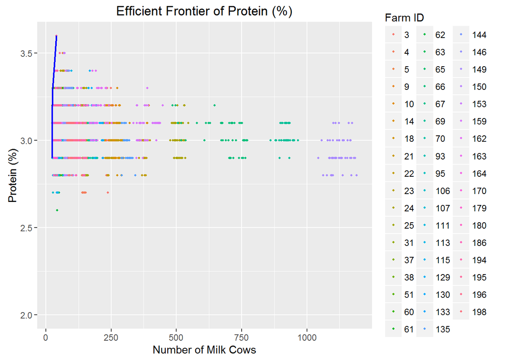

```r
ggplot(data, aes(X__Milk_Cows, X__Pro, colour = Farm_ID))+
geom_point(size = .7)+
ylim(2, 3.6)+
geom_segment(aes(x = 25, y = 2.9, xend = 25, yend = 3.2), size = .8, color = 4)+
geom_segment(aes(x = 25, y = 3.2, xend = 26, yend = 3.3), size = .8, color = 4)+
geom_segment(aes(x = 26, y = 3.3, xend = 41, yend = 3.6), size = .8, color = 4)+
xlab('Number of Milk Cows') +
ylab('Protein (%)') +
ggtitle('Efficient Frontier of Protein (%)')+
labs(colour = "Farm ID")
```

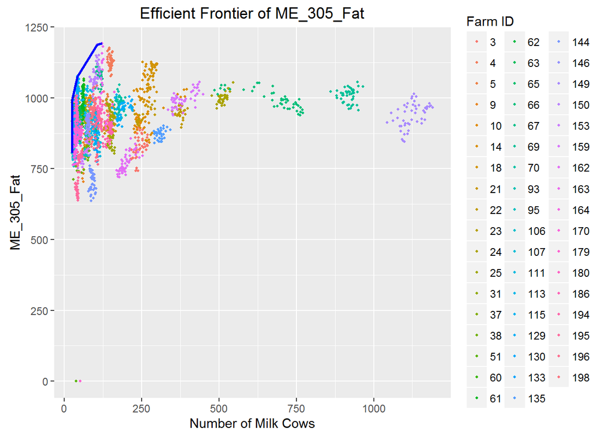

```r
ggplot(data, aes(X__Milk_Cows, ME_305_Fat, colour = Farm_ID))+
  geom_point(size = .8)+
  geom_segment(aes(x = 25, y = 806, xend = 25, yend = 992), size = .9, color = 4)+
  geom_segment(aes(x = 25, y = 992, xend = 42, yend = 1077), size = .9, color = 4)+
  geom_segment(aes(x = 42, y = 1077, xend = 43, yend = 1079), size = .9, color = 4)+
  geom_segment(aes(x = 43, y = 1079, xend = 106, yend = 1188), size = .9, color = 4)+
  geom_segment(aes(x = 106, y = 1188, xend = 122, yend = 1193), size = .9, color = 4)+
  xlab('Number of Milk Cows') +
  ylab('ME_305_Fat') +
  ggtitle('Efficient Frontier of ME_305_Fat')+
  labs(colour = "Farm ID")
```

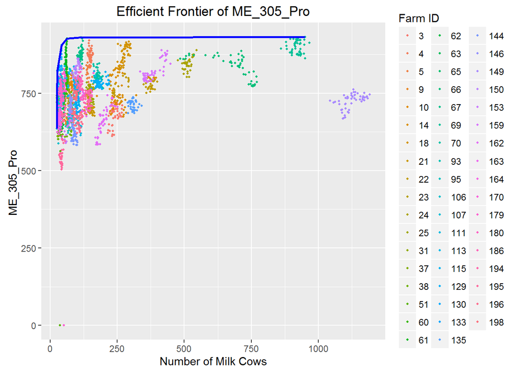

```r
ggplot(data, aes(X__Milk_Cows, ME_305_Pro, colour = Farm_ID))+
  geom_point(size = .8)+
  geom_segment(aes(x = 25, y = 635, xend = 25, yend = 742), size = .9, color = 4)+
  geom_segment(aes(x = 25, y = 742, xend = 27, yend = 823), size = .9, color = 4)+
  geom_segment(aes(x = 27, y = 823, xend = 43, yend = 905), size = .9, color = 4)+
  geom_segment(aes(x = 43, y = 905, xend = 63, yend = 927), size = .9, color = 4)+
  geom_segment(aes(x = 63, y = 927, xend = 115, yend = 930), size = .9, color = 4)+
  geom_segment(aes(x = 115, y = 930, xend = 950, yend = 932), size = .9, color = 4)+
  xlab('Number of Milk Cows') +
  ylab("ME_305_Pro ") +
  ggtitle('Efficient Frontier of ME_305_Pro')+
  labs(colour = "Farm ID")
```

## Part 4 Merge with Annual Data

Read Data:

```r
data_year = read.xlsx(file = "Annual.xlsx", 3)
data_year$Farm_ID = factor(data_year$Farm_ID)
data_new = merge(data, data_year, by = c("Farm_ID", "year"), all.x = T)
write.xlsx(data_new, file = "data_new.xlsx")
sum(data_new$Farm_ID == data$Farm_ID)
```

```
## [1] 2346
```

Check Missing Values:

```r
#Check Missing Value
missing_fn = function(col_index){
  return(sum(is.na(data_new[,col_index])))
}
result = sapply(1:dim(data_new)[2], function(x) missing_fn(x))
missing_value_new = as.data.frame(result)
missing_value_new$Var = colnames(data_new)
colnames(missing_value_new)[1] = "Number_of_Missing_Values"
missing_value_new = missing_value_new[, c(2, 1)]
knitr::kable(missing_value_new, caption = "A table produced by printr.")
```

A table produced by printr.

| Var | Number_of_Missing_Values |
| --- | --- |
| Farm_ID | 0 |
| year | 0 |
| Herdcode | 0 |
| Milk_per_Milk_Cow | 0 |
| X__Fat | 0 |
| X__Pro | 0 |
| X__Cows | 0 |
| ME_305_Milk | 11 |
| ME_305_Fat | 11 |
| ME_305_Pro | 11 |
| X__Milk_Cows | 0 |
| X_50_D_Milk | 0 |
| Peak | 11 |
| Summit | 11 |
| DHIDate | 0 |
| month | 0 |
| Sample_Number | 2184 |
| Season_Year | 2184 |
| MUN | 2185 |
| Dry_Matter | 2184 |
| CP__ | 2184 |
| NDF___DM | 2184 |
| Starch___DM | 2184 |
| Starch_Digestibility | 2184 |
| NDF_Digestibility | 2219 |
| NDF_Dig_Group | 2232 |
| Fecal_Starch | 2184 |
| pH | 2199 |
| Hybrid | 2256 |
| Structure | 2256 |
| SampleDate | 2184 |
| Parent_Company | 2291 |
| Hybrid_Company | 2289 |
| Hybrid_Name | 2291 |
| Trait | 2300 |
| relative_maturity | 2291 |
| CWT_Sold | 1434 |
| Dairy_IOFC_Surplus_Group | 1434 |
| Crop_Cost_Calc | 1434 |
| Pur_Feed_Calc | 1434 |
| Feed_Cost__All_Animals__Annual | 1434 |
| Kernel_Processed | 2346 |
| Inoculant_Applied_ | 2346 |
| Inoculent_1 | 2346 |
| Inoculent_Original | 2346 |
| Inoculent_2 | 2346 |
| Dry_Matter_Eval | 2346 |
| Particle_Size_Eval | 2346 |
| BMP2a | 2346 |
| BMP2B | 2346 |
| BMP2C | 2346 |
| BMP2D | 2346 |
| BMP3 | 2346 |
| BMP4 | 2346 |
| newyear | 2346 |
| Corn_silage | 1989 |
| Alfalfa_sil | 2151 |
| Alfalfa_hay | 2287 |
| Grass_Silage | 2295 |
| Small_Grain_Sil | 2152 |

Delete missing data:

```r
data_new_no_missing = data_new[!(is.na(data_new$Pur_Feed_Calc) |
                                  is.na(data_new$Corn_silage) |
                                  is.na(data_new$Crop_Cost_Calc)), ]
```

Do DEA for non missing data: (i)4 inputs: number of milk cows, purchased feed, corn silage, and crop cost; (ii) output: milk (lbs) per milk cow.

```r
dea_four_input = dea(cbind(data_new_no_missing$X__Milk_Cows,
                           data_new_no_missing$Pur_Feed_Calc,
                           data_new_no_missing$Corn_silage,
                           data_new_no_missing$Crop_Cost_Calc),
                     matrix(data_new_no_missing$Milk_per_Milk_Cow))
summary(dea_four_input)
```

```
## Summary of efficiencies
## The technology is vrs and input orientated efficiency
## Number of firms with efficiency==1 are 114
## Mean efficiency: 0.895
## ---
##   Eff range        #    %
##   0.6<= E <0.7    20  5.6
##   0.7<= E <0.8    63 17.6
##   0.8<= E <0.9    48 13.4
##   0.9<= E <1     112 31.4
##         E ==1    114 31.9
##    Min. 1st Qu.  Median    Mean 3rd Qu.    Max.
##   0.622   0.805   0.927   0.895   1.000   1.000
```

Plot the production efficiency frontier. Observations with efficiency 1 are marked by cross.

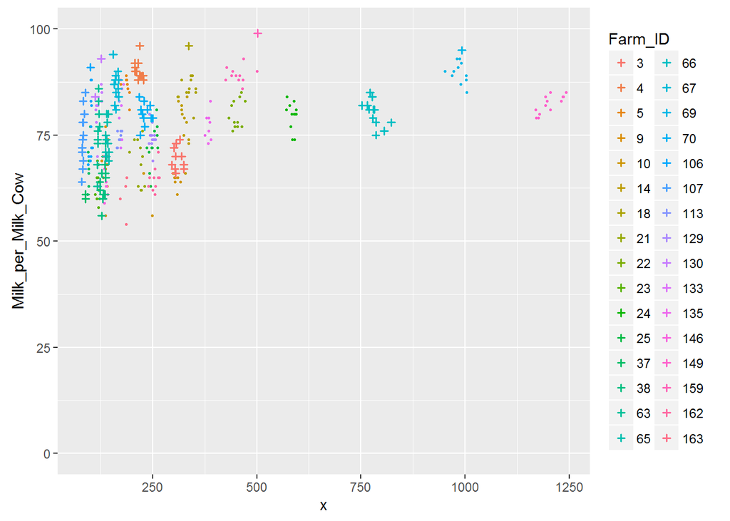

```r
ggplot(data_new_no_missing, aes(x = x, y = Milk_per_Milk_Cow, colour = Farm_ID))+
  geom_point(size = .5)+
  ylim(0, 100)+
  geom_point(data = eff_four_input, aes(x = x_eff, y = Milk_per_Milk_Cow),  size = 1, shape = 3, stroke = 1)
```

Detailed effciency coefficients

```r
eff
```

[output not shown]

[output cut: 2332 more lines]